# Flight dataset in 2008

## by Franz Tseng

## Investigation Overview

> The goal is to invastigate the trends or relationship between flights delay as well as the reason of delay with carriers and the airport location.

## Dataset Overview

> The data contains 2389217 rows of data and 29 features about fight information in the year of 2008 in US. While the whole dataset is large, I only analyze the data in 2008.

## Diversion and Cancellation Rate for Different Carriers

> The percentage of diverted and cancelled flights among different carriers in 2008 From the above analysis, I found AS has the highest diversion rate and HA has the lowest.The diversion rate for AQ, F9, and, HA are pretty low which are lower than 0.1% while 9E, AA, and AS have diversion rate higher than 0.3%, and that is 3 times higher than that of the lowest group.  
> The cancellation rate is slightly difference than diversion rate while YV has the highest rate and F9 has the lowest. I noticed that AQ, F9, and HA, the same as the lowest diversion rate group, are the airlines with least frequent concellation. YV, MQ, AA all have cancellation rate higher than 5%(9E is among the highest group, its cancellation rate is slightly lower than 5% though).  
> In terms of diversion rate and cancellation rate. AA (perhaps 9E) is in the highest frequency group.

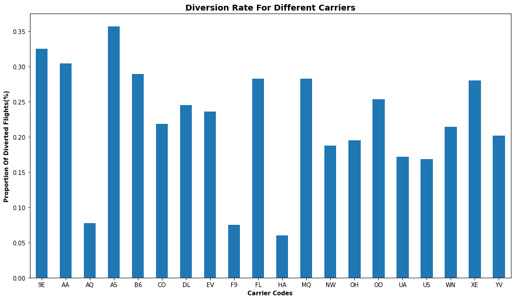

```python
df2 = df.groupby(["UniqueCarrier", "Diverted"]).size().unstack()
df2['proportion'] = (df2[1]/df.UniqueCarrier.value_counts())*100
plt.figure(figsize=[12,8])
plt.title("Diversion Rate for Different Carriers".title(),
               fontsize = 14, weight = "bold")
df2.proportion.plot(kind='bar', figsize=[14.70, 8.27])
plt.ylabel("Proportion of Diverted Flights(%)".title(),
               fontsize = 10, weight = "bold")
plt.xlabel("Carrier Codes".title(),
               fontsize = 10, weight = "bold")
plt.xticks(rotation=0);
```

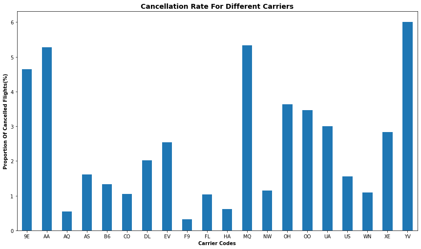

```python
df2 = df.groupby(["UniqueCarrier", "Cancelled"]).size().unstack()
df2['proportion'] = (df2[1]/df.UniqueCarrier.value_counts())*100
plt.figure(figsize=[12,8])
plt.title("Cancellation Rate for Different Carriers".title(),
               fontsize = 14, weight = "bold")
df2.proportion.plot(kind='bar', figsize=[14.70, 8.27])
plt.ylabel("Proportion of Cancelled Flights(%)".title(),
               fontsize = 10, weight = "bold")
plt.xlabel("Carrier Codes".title(),
               fontsize = 10, weight = "bold")
plt.xticks(rotation=0);
```